# Practical Machine Learning Project

Jacques Chatard

April 4 2019

# Purpose of this project and data source

**In this project we will use and compare 3 different models on WLE (weight lifting exercises) dataset.**

1- A Boosted trees model ‘modlgbm’.  
2- A Linear discriminant analysis model ‘modllda’.  
3- A Random forest model ‘modlrf’.

**And we will try to estimate the accuracy of the predictions on the ‘classe’** **variable which classifies the quality of execution of weight lifting movements.**

This project is related to the human activity recognition ‘HAR’. We will use the WLE dataset collected by :

Velloso, E.; Bulling, A.; Gellersen, H.; Ugulino, W.; Fuks, H. Qualitative Activity Recognition of Weight Lifting Exercises. Proceedings of 4th International Conference in Cooperation with SIGCHI (Augmented Human ’13) . Stuttgart, Germany: ACM SIGCHI, 2013.  
Many thanks for their generosity.

### Url about WLE data set:

[more info](http://groupware.les.inf.puc-rio.br/har#weight_lifting_exercises)

### Rmd file of this page :

[Github rmd file:](https://github.com/chatard/PML-Coursera-Project/blob/gh-pages/assignment.Rmd)

# Loading and reading data

- Loading data:

```r
destfile="pml-training.csv"
fileURL<- "https://d396qusza40orc.cloudfront.net/predmachlearn/pml-training.csv"
if (!file.exists(destfile)) {
        download.file(fileURL ,destfile,method="auto")
}
```

```r
destfile="pml-testing.csv"
fileURL<- "https://d396qusza40orc.cloudfront.net/predmachlearn/pml-testing.csv"
if (!file.exists(destfile)) {
        download.file(fileURL ,destfile,method="auto")
}
```

- Reading data:

```r
pml_training<-read.table(file = "pml-training.csv", header=TRUE, sep=",")
pml_testing <-read.table(file ="pml-testing.csv", header=TRUE, sep=",")
dim(pml_training); dim(pml_testing)
```

```
## [1] 19622   160
```

```
## [1]  20 160
```

# loading the required libraries:

```r
library(caret); library(kernlab); library(randomForest); library(dplyr)
library(parallel); library(foreach); library(doParallel); library(lattice)
```

The original data is already divided into two groups of data: pml-training and pml-testing. Nevertheless, pml-testing represents only 1 per thousand of the total data. I would proceed to a new subdivision of the data from pml-training.

# Cleaning the data:

To get clean data, I will use the original data that comes from ‘pml_training’.

## Near-zero variance predictors:

1 . I will remove them from the data.

2 . checking if outcome ‘classe’ variable has not disappeared.

```r
x = nearZeroVar(pml_training)
newBaseData <- pml_training[, -x]
dim(newBaseData)
```

```
## [1] 19622   100
```

```r
#checking if outcome 'classe' variable has not disappeared :
"classe" %in% names(newBaseData)
```

```
## [1] TRUE
```

## Also, I will remove column of variables with na values:

```r
NA_cols <- sapply(newBaseData, function(x) sum(is.na(x))) >0
newBaseData<-newBaseData[, NA_cols==FALSE]
dim(newBaseData)
```

```
## [1] 19622    59
```

## And finally, I will remove the first 6 columns of variables:

These variables relate to the identification of participants and the time periods in which observations were recorded and these variables are not predictor variables.

```r
newBaseData <- newBaseData[, -(1:6)]
dim(newBaseData)
```

```
## [1] 19622    53
```

# Splitting: cleaned data partition:

```r
inTrain <- createDataPartition(newBaseData$classe, p =0.70, list = FALSE)
training <- newBaseData[inTrain,]
testing <- newBaseData[-inTrain,]
dim(training);dim(testing)
```

```
## [1] 13737    53
```

```
## [1] 5885   53
```

# Defining three models

## Before definining models we have to define training control:

In order to optimize the training phase to the RAM resources available I have to find a suitable configuration. So I configure a ‘traincontrol’ object:  
I choose a 5-fold for cross-validation:

```r
set.seed(1234)
Ctrl <- trainControl(method = "cv",
                           number = 5,
                           allowParallel = TRUE)
```

## Models:

Each of the 3 models will use the named variable **“classe” as outcome variable**. It is the criterion of judgment of the good execution of the weight lifting. ‘A’ corresponds to a correctly performed movement. The 4 other classes are a classification of specific mistakes in the realization of the movement.

**1- Boosted trees model:**

```r
# Boosted trees model:

set.seed(1234)
modlgbm <- train(classe ~ ., data= training, method="gbm", trControl=Ctrl, verbose = FALSE)
#modlgbm
```

**2- Linear discriminant analysis model:**

```r
# Linear discriminant analysis model:
set.seed(1234)
modllda <- train(classe ~ ., data =training, method="lda", trControl=Ctrl, verbose = FALSE)
#modllda
```

**3- Random Forest model:**

```r
# Random Forest model:
set.seed(1234)
modlrf <- train(classe ~., method="rf", data=training, trControl=Ctrl, verbose = FALSE)
#modlrf
```

## Variable importance:

Finding the most important predictors: Here I use the caret package function varimp() to find most important predictors with a specific model (random forest).

And I plot the Top 20 predictors.

```r
varImp(modlrf)
```

```
## rf variable importance
##
##   only 20 most important variables shown (out of 52)
##
##                      Overall
## roll_belt            100.000
## pitch_forearm         59.896
## yaw_belt              54.073
## magnet_dumbbell_z     44.199
## pitch_belt            43.138
## magnet_dumbbell_y     42.921
## roll_forearm          37.808
## accel_dumbbell_y      23.195
## roll_dumbbell         18.327
## accel_forearm_x       17.102
## magnet_dumbbell_x     15.854
## magnet_belt_z         14.903
## magnet_forearm_z      13.966
## accel_dumbbell_z      13.324
## total_accel_dumbbell  13.099
## magnet_belt_y         13.077
## accel_belt_z          11.025
## yaw_arm               10.799
## gyros_belt_z           9.536
## roll_arm               9.110
```

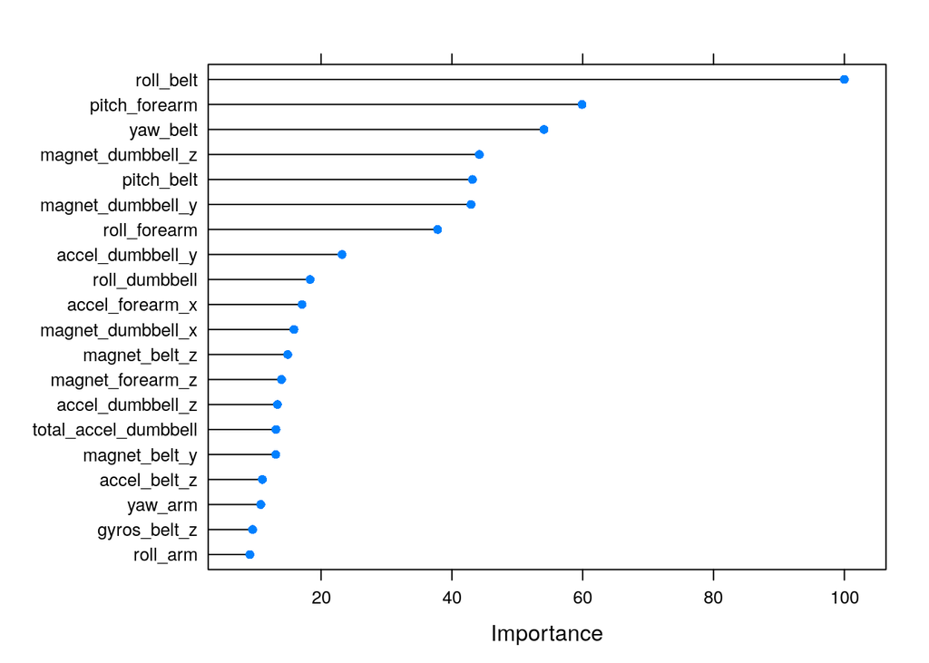

```r
plot(varImp(modlrf),top=20)
```

```r
#modlrf$finalModel
```

# Comparison of the 3 models:

### Out of sample error:

It’s important to have an idea of ‘out sample error’ for each of the models. For that we will make the estimate on a resampling.

```r
results <- resamples(list(GBM=modlgbm, LDA=modllda, RF=modlrf))
summary(results)
```

```
##
## Call:
## summary.resamples(object = results)
##
## Models: GBM, LDA, RF
## Number of resamples: 5
##
## Accuracy
##          Min.   1st Qu.    Median      Mean   3rd Qu.      Max. NA's
## GBM 0.9545124 0.9559519 0.9585002 0.9592344 0.9628956 0.9643117    0
## LDA 0.6949399 0.6983261 0.7035286 0.7032115 0.7040408 0.7152221    0
## RF  0.9912664 0.9916272 0.9923525 0.9924291 0.9934474 0.9934522    0
##
## Kappa
##          Min.   1st Qu.    Median      Mean   3rd Qu.      Max. NA's
## GBM 0.9424323 0.9443175 0.9474806 0.9484237 0.9530484 0.9548397    0
## LDA 0.6139058 0.6187180 0.6242564 0.6243908 0.6255265 0.6395471    0
## RF  0.9889510 0.9894068 0.9903257 0.9904225 0.9917115 0.9917177    0
```

```r
RFoutSample<-1-mean(results$values[, "RF~Accuracy"])
GBMoutSample<-1-mean(results$values[, "GBM~Accuracy"])
LDAoutSample<-1-mean(results$values[, "LDA~Accuracy"])
```

| model | out of sample error |
| --- | --- |
| RF | 0.0075709 |
| GBM | 0.0407656 |
| LDA | 0.2967885 |

# Model selection:

From this comparison, it follows that the best model is: random forest model. So this is the one I will choose.

## Sampling in training

```r
trainingSample = predict(modlrf, training)
confusionMatrix(training$classe, trainingSample)
```

```
## Confusion Matrix and Statistics
##
##           Reference
## Prediction    A    B    C    D    E
##          A 3906    0    0    0    0
##          B    0 2658    0    0    0
##          C    0    0 2396    0    0
##          D    0    0    0 2252    0
##          E    0    0    0    0 2525
##
## Overall Statistics
##
##                Accuracy : 1
##                  95% CI : (0.9997, 1)
##     No Information Rate : 0.2843
##     P-Value [Acc > NIR] : < 2.2e-16
##
##                   Kappa : 1
##  Mcnemar's Test P-Value : NA
##
## Statistics by Class:
##
##                      Class: A Class: B Class: C Class: D Class: E
## Sensitivity            1.0000   1.0000   1.0000   1.0000   1.0000
## Specificity            1.0000   1.0000   1.0000   1.0000   1.0000
## Pos Pred Value         1.0000   1.0000   1.0000   1.0000   1.0000
## Neg Pred Value         1.0000   1.0000   1.0000   1.0000   1.0000
## Prevalence             0.2843   0.1935   0.1744   0.1639   0.1838
## Detection Rate         0.2843   0.1935   0.1744   0.1639   0.1838
## Detection Prevalence   0.2843   0.1935   0.1744   0.1639   0.1838
## Balanced Accuracy      1.0000   1.0000   1.0000   1.0000   1.0000
```

## Sampling in testing

```r
testingSample = predict(modlrf, testing)
confusionMatrix(testing$classe,testingSample)
```

```
## Confusion Matrix and Statistics
##
##           Reference
## Prediction    A    B    C    D    E
##          A 1673    0    1    0    0
##          B   11 1126    2    0    0
##          C    0   10 1011    5    0
##          D    0    0    7  956    1
##          E    0    0    1    7 1074
##
## Overall Statistics
##
##                Accuracy : 0.9924
##                  95% CI : (0.9898, 0.9944)
##     No Information Rate : 0.2862
##     P-Value [Acc > NIR] : < 2.2e-16
##
##                   Kappa : 0.9903
##  Mcnemar's Test P-Value : NA
##
## Statistics by Class:
##
##                      Class: A Class: B Class: C Class: D Class: E
## Sensitivity            0.9935   0.9912   0.9892   0.9876   0.9991
## Specificity            0.9998   0.9973   0.9969   0.9984   0.9983
## Pos Pred Value         0.9994   0.9886   0.9854   0.9917   0.9926
## Neg Pred Value         0.9974   0.9979   0.9977   0.9976   0.9998
## Prevalence             0.2862   0.1930   0.1737   0.1645   0.1827
## Detection Rate         0.2843   0.1913   0.1718   0.1624   0.1825
## Detection Prevalence   0.2845   0.1935   0.1743   0.1638   0.1839
## Balanced Accuracy      0.9966   0.9942   0.9931   0.9930   0.9987
```

# Predicting Classe of Testing Data Set

Utilize the prediction model on the testing data set.

```r
predictRF <- predict(modlrf, newdata=pml_testing)
predictRF
```

```
##  [1] B A B A A E D B A A B C B A E E A B B B
## Levels: A B C D E
```